# Narendra Modi Twitter Analysis

[figure not shown]

### Total Number of Tweets

3220

### Average Number of ReTweets

2051.08

### Average Number of Favorites

6026.3

### **Top 5 hashtags used by Narendra Modi for the period Jan-2016 to Dec-2016.** <>

[interactive chart not shown]

### **Top 6 words used by Narendra Modi in tweets from Q1-2016 to Q4-2016.**<>

[interactive chart not shown]

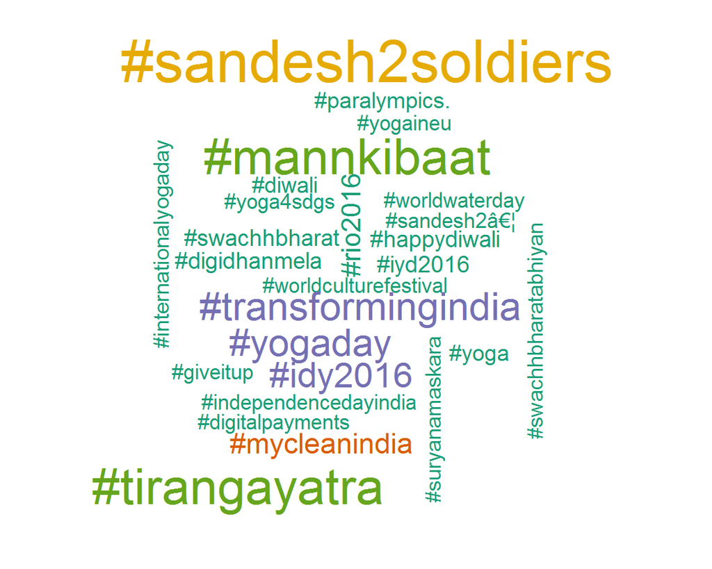

### **Days on which Narendra modi tweeted the most.**<>

[interactive chart not shown]

### **Days on which Retweets are the most.**<>

[interactive chart not shown]

### **Analysing the above Heatmaps,the following trends were found in the data:**

- **Narendra Modi made maximum amount of tweets on 21st June 2016 which is the International Yoga Day.**<>
- **It is also noticed that Narendra Modi tweeted alot on 17th September 2016,which happens to be his birthday.He visited his Mother in his hometown and attended alot of functions in Gujrat about which he semms to have tweeted**<>
- **Modi seems to have tweeted alot on 4th July 2016 too,investigating the tweets shows that Modi met the Rio Olympics 2016 Indian Contingent on that day and tweeted alot about the same.**<>
- **Alot of Modis tweets were retweeted between 8th November 2016 and 9th November 2016,which are pricisely the days Modi announced demonitization of Rs. 500 and Rs.1000 notes.**<>